# Usage SNS package

Luis Benavides

2019-05-30

Install the package `SNS` hosted in [github](https://github.com/LuisBenavides/sns).

```r
install_github("LuisBenavides/SNS")
```

Load the package

```r
library("SNS")
```

## Using Sequential Normal Scores to Detect a Change in Location (Shewhart Scheme)

### Example 3.1.1.

Get dataset from Example 8.2 by Qiu (2013) (see Example 3.1.1 from Conover, Tercero, and Cordero-Franco (2019))

```r
X = example82$X
X.id = example82$X.id
```

Table with the dataset using dataframe of (first 10 rows).

| X | X.id |
| --- | --- |
| -0.623 | 1 |
| -1.068 | 1 |
| 0.605 | 1 |
| -0.002 | 1 |
| -0.807 | 1 |
| -0.105 | 2 |
| -0.037 | 2 |
| -0.595 | 2 |
| 1.222 | 2 |
| -0.545 | 2 |

Get the sns of the dataset

```r
s = SNS(X=X,X.id=X.id)
```

to plot it

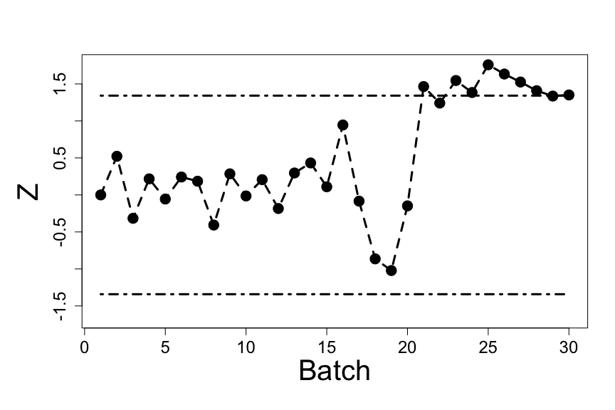

```r
plot(s)
```

## CUSUM Variation to Detect a Change in Location

### Example 3.2.1.

Get dataset from Example 8.4 by Qiu (2013) (see Example 3.2.1 from Conover, Tercero, and Cordero-Franco (2019))

```r
X = example84$X
X.id = example84$X.id
```

Table with the dataset using dataframe of (first 10 rows).

| X | X.id |
| --- | --- |
| -0.393 | 1 |
| -0.685 | 1 |
| 0.360 | 1 |
| 0.148 | 1 |
| 0.867 | 1 |
| -0.552 | 2 |
| -0.462 | 2 |
| -0.979 | 2 |
| -0.580 | 2 |
| -0.008 | 2 |

Get the sns of the dataset using a CUSUM scheme

```r
s = SNS(X=X,X.id=X.id, chart="CUSUM", chart.par=c(0.5, 4.389, 3))
```

to plot it

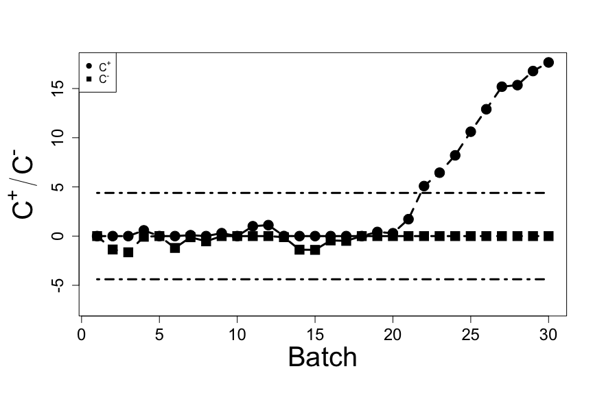

```r
plot(s)
```

## EWMA Variation to Detect a Change in Location

### Example 3.3.1.

Load package and get dataset from Example 8.4 by Qiu (2013) (Example 3.2.1 from Conover, Tercero, and Cordero-Franco (2019))

```r
X = example84$X
X.id = example84$X.id
```

Table with the dataset using dataframe of (first 10 rows).

| X | X.id |
| --- | --- |
| -0.393 | 1 |
| -0.685 | 1 |
| 0.360 | 1 |
| 0.148 | 1 |
| 0.867 | 1 |
| -0.552 | 2 |
| -0.462 | 2 |
| -0.979 | 2 |
| -0.580 | 2 |
| -0.008 | 2 |

Get the sns of the dataset using a EWMA scheme

```r
s = SNS(X=X,X.id=X.id, chart="EWMA", chart.par=c(0.1, 2.814))
```

to plot it

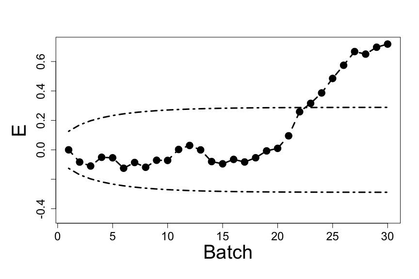

```r
plot(s)
```

## Sequential Normal Scores with a Reference Data Set (Phase 1)

### Example 3.5.1.

Load package and get dataset from Example 8.7 by Qiu (2013) (Example 3.5.1 from Conover, Tercero, and Cordero-Franco (2019))

```r
X = example87$X
X.id = example87$X.id
Y = example87$Y
```

Table with the dataset using dataframe of (first 10 rows).

| X | X.id | Y |
| --- | --- | --- |
| -0.034 | 1 | -0.333 |
| -0.103 | 2 | -0.039 |
| 0.463 | 3 | 0.071 |
| 0.193 | 4 | -0.303 |
| 0.723 | 5 | -0.712 |
| 1.362 | 6 | 0.294 |
| -0.366 | 7 | -0.421 |
| -0.610 | 8 | -0.241 |
| 0.012 | 9 | 0.740 |
| 0.269 | 10 | 0.534 |

Get the sns of the dataset using a EWMA scheme

```r
s = SNS(X=X,X.id=X.id, Y=Y, chart="EWMA", chart.par=c(0.1, 2.814))
```

to plot it

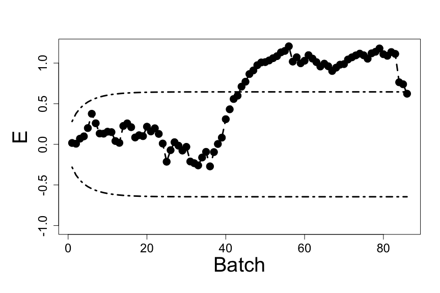

```r
plot(s)
```

## Detecting a Change in Both Location and Scale (SNS Method)

### Example 4.3.1

Load package and get dataset from Example 4.9 by Qiu (2013) (Example 4.3.1 from Conover, Tercero, and Cordero-Franco (2019))

```r
X = example49$X2
X.id = example49$X.id
Y = example49$Y2
```

Table with the dataset using dataframe of (first 10 rows).

| X1 | X2 | Y1 | Y2 | X.id |
| --- | --- | --- | --- | --- |
| 0.5993625 | -0.7822084 | 0.0187462 | -0.7618043 | 1 |
| 0.6654434 | -0.4997350 | -0.1842525 | 0.4193754 | 1 |
| 2.3679540 | 2.3102095 | -1.3713305 | -1.0399434 | 1 |
| 3.1377671 | -1.7294545 | -0.5991677 | 0.7115740 | 1 |
| 1.5058193 | -1.7333567 | 0.2945451 | -0.6332130 | 1 |
| 1.7863424 | -4.6420341 | 0.3897943 | 0.5631747 | 2 |
| 0.0977881 | 1.2176603 | -1.2080762 | 0.6609867 | 2 |
| 1.5328970 | 2.3000121 | -0.3636760 | -1.6580509 | 2 |
| 0.3541057 | -2.3991953 | -1.6266727 | 1.0281680 | 2 |
| 1.2909875 | -3.1600015 | -0.2564784 | 1.1279536 | 2 |

```r
s = SNS(X=X,X.id=X.id, Y=Y, chart="Shewhart", scoring="Z-SQ",isFixed = TRUE)
```

to plot it. Only the plot of the monitoring sample is presented.

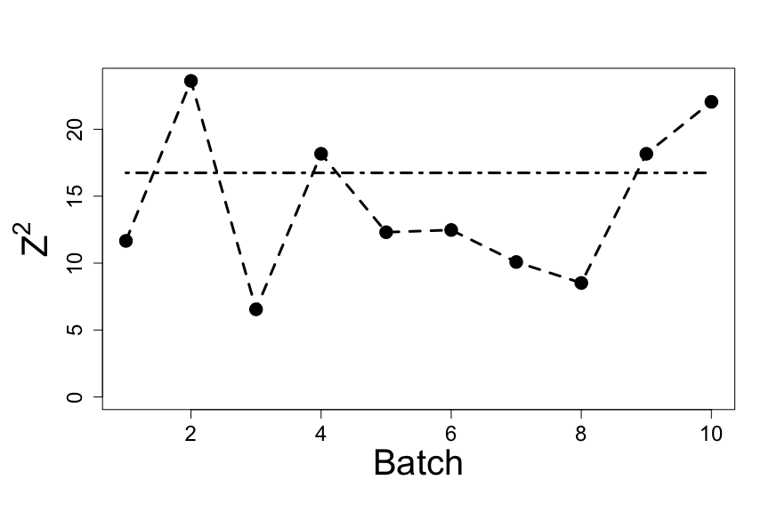

```r
plot(s)
```

## Multivariate Sequential Normal Scores to Detect a Change in Location

### Example 6.1.1.

Get dataset from Example 9.1 by Qiu (2013) (see Example 6.1.1 from Conover, Tercero, and Cordero-Franco (2019)).

```r
X = example91[,1:2]
X.id = example91$X.id
```

Table with the dataset using dataframe of (first 10 rows).

| X1 | X2 | X.id |
| --- | --- | --- |
| -0.692 | -1.230 | 1 |
| 0.165 | 0.267 | 1 |
| -0.153 | -0.325 | 1 |
| 0.289 | -1.325 | 1 |
| 0.140 | 0.211 | 1 |
| 0.188 | -0.236 | 1 |
| 0.072 | 2.337 | 1 |
| 0.685 | 0.614 | 1 |
| -1.245 | -1.013 | 1 |
| -0.153 | 0.189 | 1 |

Get the multivariate sequential normal scores

```r
msns = MSNS(X, X.id)
```

and plot it

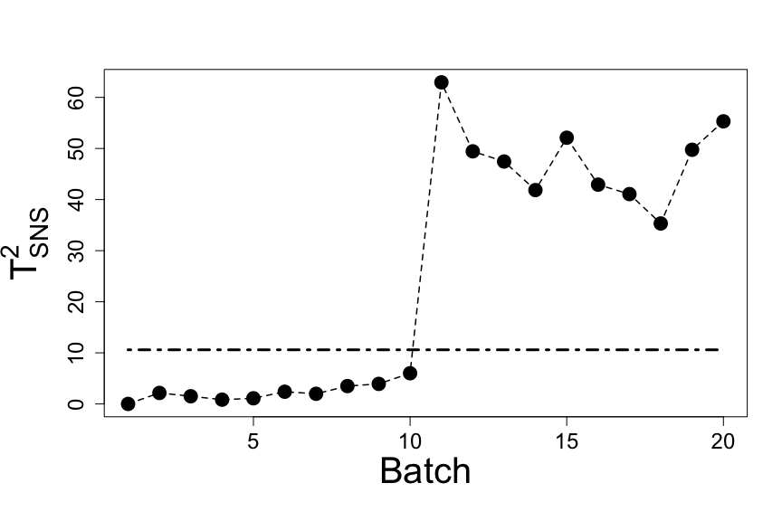

```r
plot(msns)
```

## Multivariate Sequential Normal Scores to Detect a Change in Location

### Example 6.2.1.

Get dataset from Example 9.3 by Qiu (2013) (see Example 6.2.1 from Conover, Tercero, and Cordero-Franco (2019)).

```r
X = example93[,1:2]
X.id = example93$X.id
```

Table with the dataset using dataframe of (first 10 rows).

| X1 | X2 | X.id |
| --- | --- | --- |
| -1.197 | -1.060 | 1 |
| -0.536 | -0.447 | 1 |
| 1.302 | 1.826 | 1 |
| -0.449 | 0.933 | 1 |
| -2.569 | -2.584 | 1 |
| -0.805 | -0.594 | 1 |
| -0.584 | -0.069 | 1 |
| -1.635 | -2.966 | 1 |
| 1.679 | -1.278 | 1 |
| -0.122 | 0.274 | 1 |

```r
msns = MSNS(X, X.id, null.dist = "F")
```

and plot it

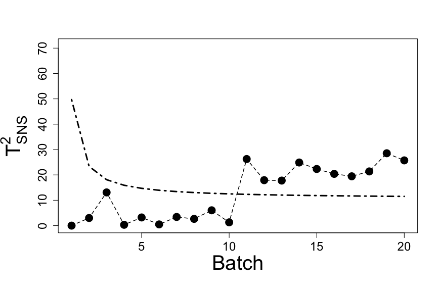

```r
plot(msns)
```

# References

Conover, WJ, Victor G Tercero, and Alvaro E Cordero-Franco. 2019. “An Approach to Statistical Process Control That Is New, Nonparametric, Simple, and Powerful.” *arXiv Preprint arXiv:1901.04443*.

Qiu, Peihua. 2013. *Introduction to Statistical Process Control*. Chapman; Hall/CRC.